# NowEDA Playground — 0.2.3

## 2. `df.eda.vizall()` — Explore visually

Use charts after the statistical assessment identifies areas worth exploring. `vizall()` ranks descriptive charts within a panel budget and, when appropriate, fits small disposable visual baselines for regression, logistic probability, linear versus nonlinear SVM boundaries, and PCA-projected K-Means structure. These diagnostics guide validation; they are not production models.

Small mode uses every loaded row by default. Pass `sample=10_000` (or another positive integer) to bound `statsall()`, `vizall()`, or `mlall()`. Large mode uses `sample=10_000` by default; change it up or down per method.

### General structure and exploratory clustering

Without a target, NowEDA ranks distributions, missingness, outliers, feature scales, associations, numeric relationships, and temporal patterns. When usable numeric structure exists, it also compares K-Means silhouette scores and shows a two-dimensional PCA projection. `max_plots` counts individual panels.

```
[########################] 100% NowEDA · Rendering visualizations
```

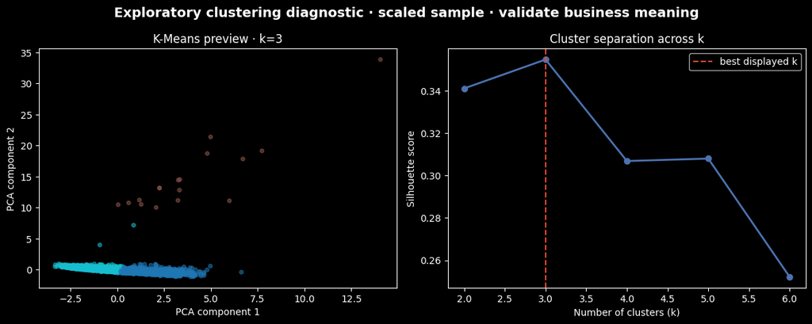

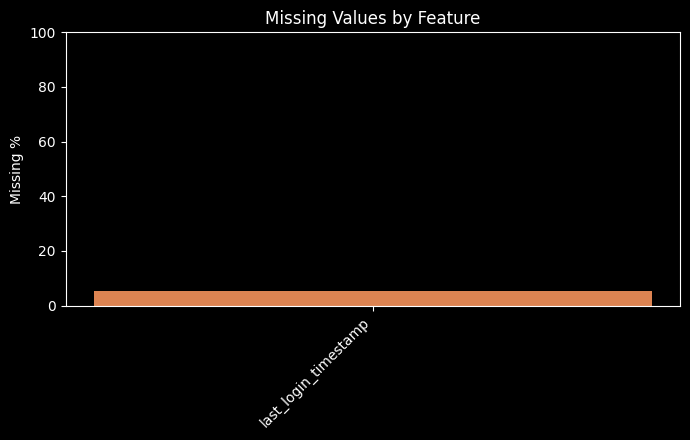

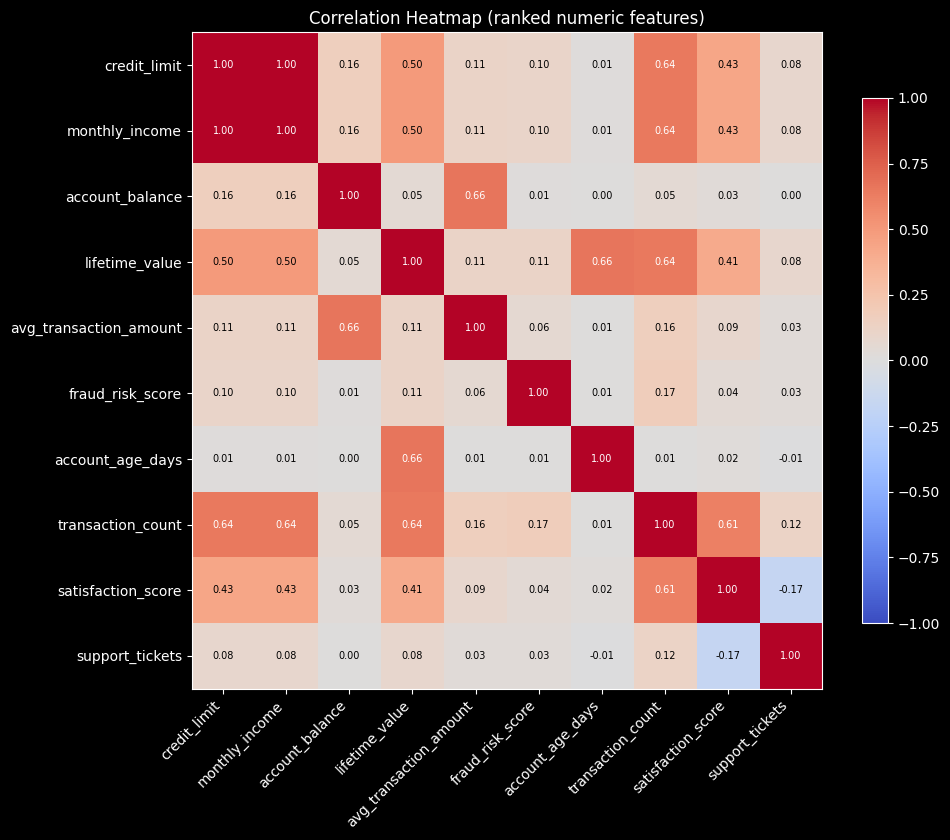

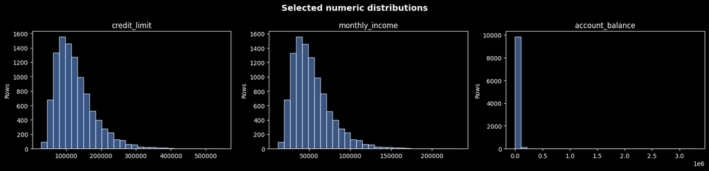

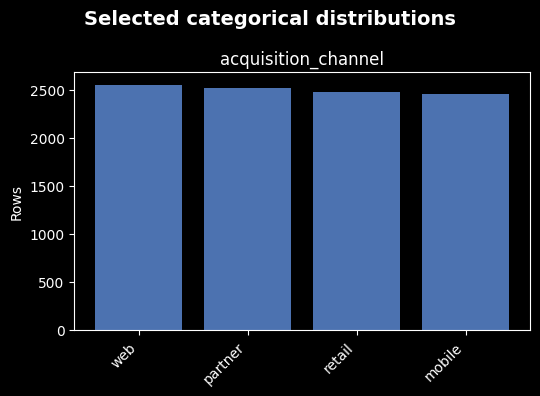

```
[{'model': 'kmeans_pca_preview', 'features': ['lifetime_value', 'credit_limit', 'transaction_count', 'satisfaction_score', 'avg_transaction_amount', 'account_balance'], 'rows': 3000, 'best_k': 3, 'validation_metric': 'silhouette', 'validation_score': 0.3546, 'scores_by_k': {2: 0.341, 3: 0.3546, 4: 0…
```

```
NowEDA VizResult(target=None, problem_type=None, plots=8, selected_features=12)
```

```python
# Small mode: chart and supporting analysis use all loaded rows.
general_visuals = df.eda.vizall(max_plots=8)
print(general_visuals['diagnostic_models'])
general_visuals

# For a quicker bounded analysis and chart set, use:
# df.eda.vizall(sample=5_000, max_plots=8)
```

### Logistic probability and linear classification

`churned` has an interpretable relationship with transaction activity, satisfaction, inactivity, and support demand. This call shows class balance, a logistic probability curve, and side-by-side linear and nonlinear SVM boundaries. Validation scores describe only the displayed diagnostic projection.

```
[########################] 100% NowEDA · Rendering visualizations
```

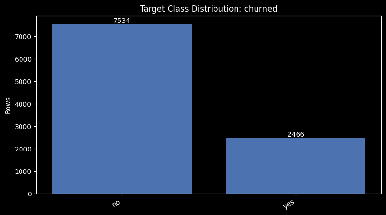

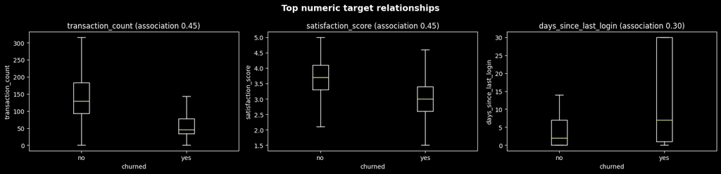

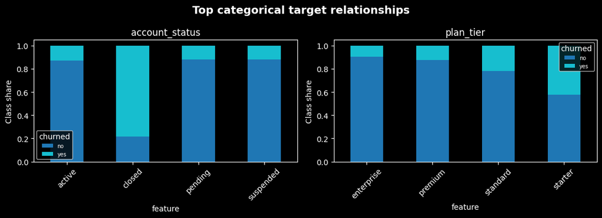

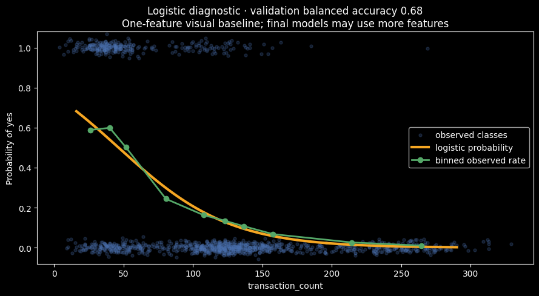

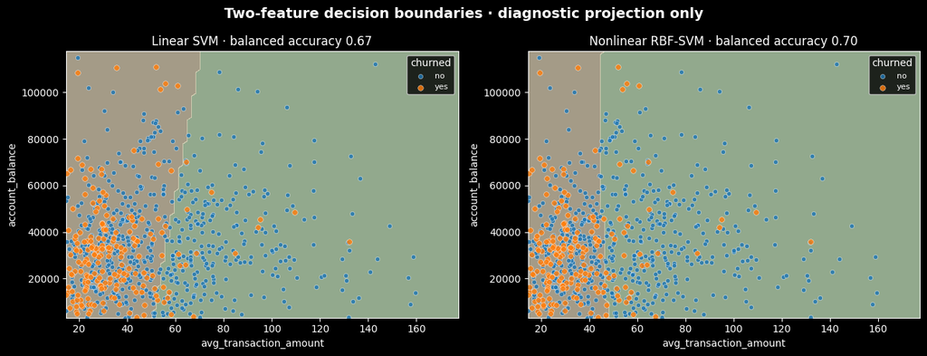

```
Visual ML signals
  - Approximately linear target structure appears in transaction_count, satisfaction_score, days_since_last_login; logistic regression or a linear SVM is a reasonable baseline to validate.
  - Curved or threshold-like target structure appears in avg_transaction_amount, account_balance; compare tree-based or nonlinear-kernel models.
  - Choose between linear and nonlinear classifiers with stratified validation; visual separation alone is not decisive.
```

```
[{'model': 'logistic_regression', 'features': ['transaction_count'], 'rows': 3000, 'validation_metric': 'balanced_accuracy', 'validation_score': 0.6849, 'scope': 'one-feature diagnostic train/validation fit'}, {'model': 'linear_svm', 'features': ['avg_transaction_amount', 'account_balance'], 'rows':…
```

```
NowEDA VizResult(target='churned', problem_type='classification', plots=9, selected_features=7)
```

```python
churn_visuals = df.eda.vizall(
    target="churned",
    max_plots=9,
)
print(churn_visuals['diagnostic_models'])
churn_visuals
```

### Nonlinear classification and leakage

`fraud_flag` is intentionally imbalanced and contains a curved interaction. `fraud_risk_score` is an intentionally suspicious post-outcome proxy, so NowEDA should warn about leakage and omit it from fitted diagnostic boundaries.

```
[########################] 100% NowEDA · Rendering visualizations
```

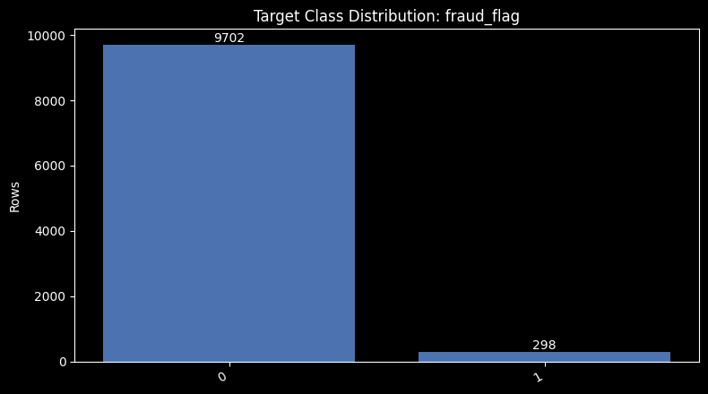

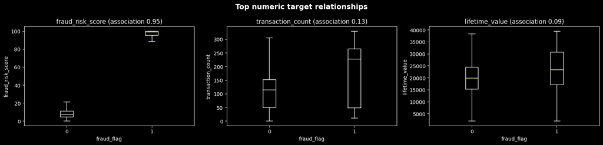

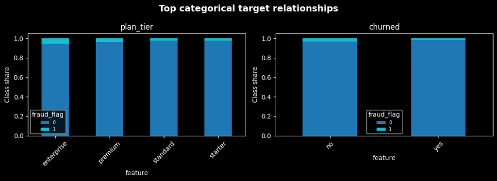

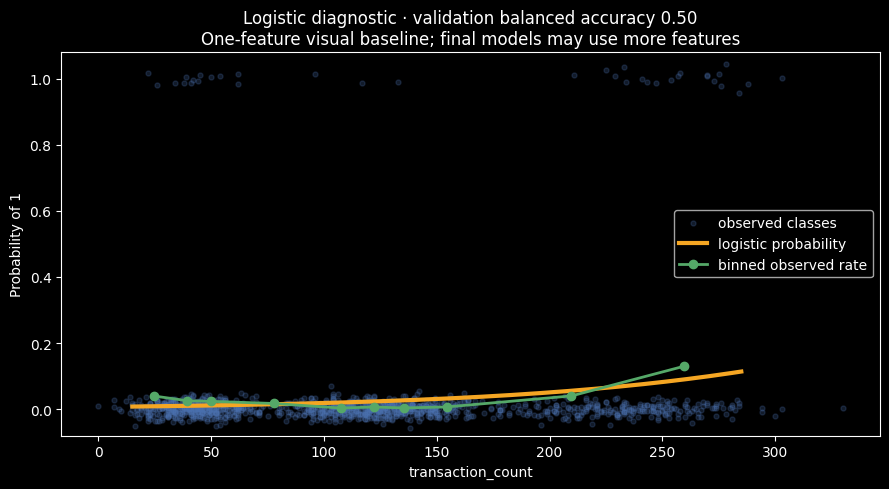

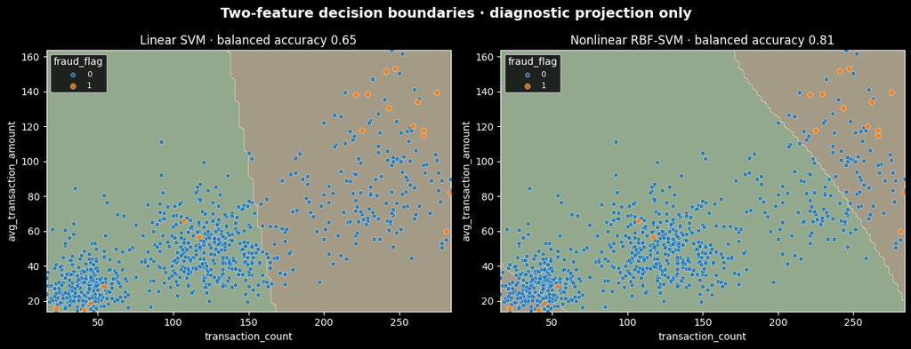

```
Visual ML signals
  - Possible target leakage: fraud_risk_score has a near-deterministic univariate association; verify when it becomes available.
  - Curved or threshold-like target structure appears in transaction_count, avg_transaction_amount; compare tree-based or nonlinear-kernel models.
  - Choose between linear and nonlinear classifiers with stratified validation; visual separation alone is not decisive.
```

```
Possible leakage: ['fraud_risk_score']
[{'model': 'logistic_regression', 'features': ['transaction_count'], 'rows': 3000, 'validation_metric': 'balanced_accuracy', 'validation_score': 0.5, 'scope': 'one-feature diagnostic train/validation fit'}, {'model': 'linear_svm', 'features': ['transaction_count', 'avg_transaction_amount'], 'rows': …
```

```
NowEDA VizResult(target='fraud_flag', problem_type='classification', plots=9, selected_features=6)
```

```python
fraud_visuals = df.eda.vizall(
    target="fraud_flag",
    max_plots=9,
)
print('Possible leakage:', fraud_visuals['leakage_candidates'])
print(fraud_visuals['diagnostic_models'])
fraud_visuals
```

### Regression fit and residual behavior

`lifetime_value` provides a continuous target with mostly linear structure and realistic noise. The diagnostic includes a fitted line, held-out validation R², and residuals alongside the broader target relationships.

```
[########################] 100% NowEDA · Rendering visualizations
```

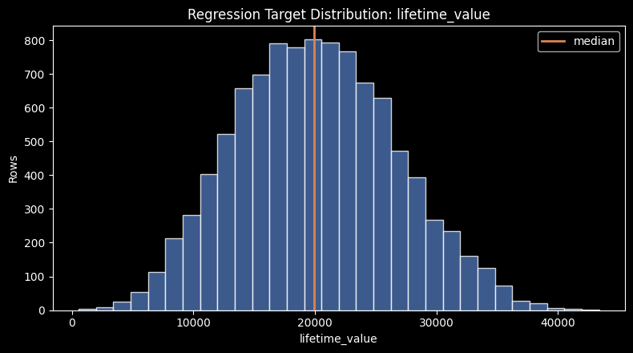

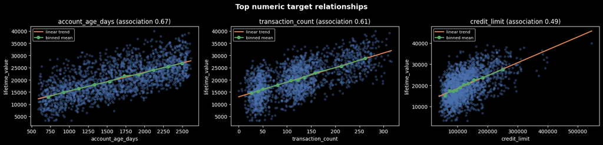

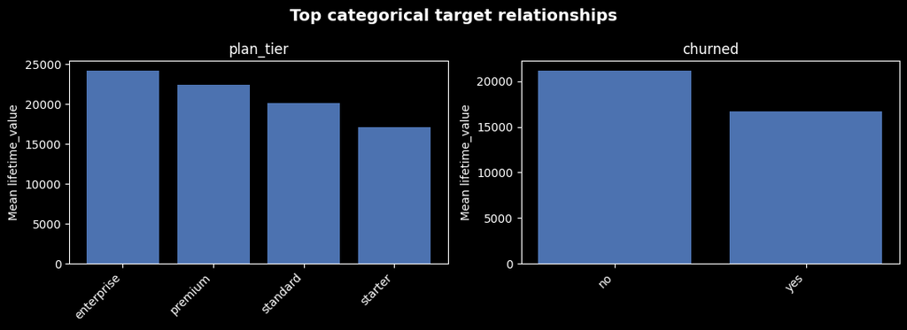

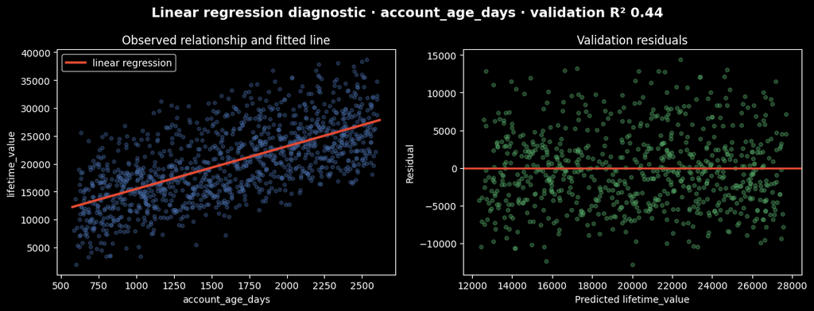

```
Visual ML signals
  - Approximately linear target structure appears in account_age_days, transaction_count; linear regression is a reasonable baseline to validate.
  - Curved or threshold-like target structure appears in avg_transaction_amount; compare tree-based or nonlinear-kernel models.
  - Compare linear and nonlinear regressors with validation; residual behavior and predictive metrics decide the final model.
```

```
[{'model': 'linear_regression', 'features': ['account_age_days'], 'rows': 3000, 'validation_metric': 'r2', 'validation_score': 0.4364, 'scope': 'diagnostic train/validation fit'}]
```

```
NowEDA VizResult(target='lifetime_value', problem_type='regression', plots=8, selected_features=5)
```

```python
regression_visuals = df.eda.vizall(
    target="lifetime_value",
    max_plots=8,
)
print(regression_visuals['diagnostic_models'])
regression_visuals
```

## 3. `df.eda.mlall()` — Choose an ML direction

Start without arguments when the objective is unknown. Then name the outcome column for supervised guidance.

```python
# Small mode uses all loaded rows unless `sample=` is supplied.
# Start with an objective-free assessment, then name the target you intend to predict.
df.eda.mlall()

classification_features = [
    'transaction_count', 'satisfaction_score', 'days_since_last_login',
    'support_tickets', 'plan_tier'
]

# Infer the supervised problem from the named target, print guidance, and inspect it.
classification_plan = df.eda.mlall(
    target='churned',
    features=classification_features,
    plan=True,
)

# Example bounded ML guidance: df.eda.mlall(target='churned', sample=5_000)
print(
    classification_plan['problem_type'],
    classification_plan['problem_subtype'],
    '—',
    classification_plan['inference_reason'],
)
```

```
[########################] 100% NowEDA · Building ML recommendations
```

```
======================================================================
  NowEDA · Task-Aware ML Guidance
======================================================================

  Dataset ML assessment
  Usable features: 26
  Supervised readiness: Ready
  Unsupervised readiness: High

  Potential targets — review before selecting one
    • 'account_status': 10000 labels (100.0%), classification, Ready
    • 'churned': 10000 labels (100.0%), classification, Ready
    • 'fraud_flag': 10000 labels (100.0%), classification, Ready

  Recommended analytical directions (estimated fit)
  --------------------------------------------------------------

  clustering
    Estimated fit: ★★★★★ (4.5/5)
    Why: Multiple usable features can support exploratory segmentation after preprocessing.
    Start with: K-Modes or K-Prototypes

  dimensionality_reduction
    Estimated fit: ★★★★★ (4.5/5)
    Why: Several features may benefit from compact exploratory representations.
    Start with: Multiple Correspondence Analysis

  anomaly_detection
    Estimated fit: ★★★★☆ (3.5/5)
    Why: Multiple usable numeric features can be screened for unusual combinations.
    Start with: Isolation Forest

  Review before modeling:
    • Likely identifier feature(s) were excluded from automatic ML assessment: ['record_id', 'customer_id'].
    • Possible target column(s) were excluded from automatic unsupervised guidance: ['account_status', 'churned', 'fraud_flag', 'fraud_risk_score'].

  Preparation
  --------------------------------------------------------------
    1. Choose imputers on training data only; preserve missingness indicators when meaningful.
    2. Encode categorical features inside the fitted pipeline; handle unseen categories.
    3. Scale numeric features for distance-, margin-, and component-based methods.
    4. Review correlated features; regularization or dimensionality reduction may improve stability.
    5. Exclude identifiers and features unavailable at the point where the method will be used.

  Select target= for supervised guidance, or problem_type= for a focused unsupervised review.
  Guidance is based on data characteristics; no models were trained or measured.
======================================================================
```

```
[########################] 100% NowEDA · Building ML recommendations
```

```
======================================================================
  NowEDA · Task-Aware ML Guidance
======================================================================

  Problem type: classification
  Subtype: binary
  Target: 'churned'
  Usable labels: 10,000 of 10,000
  Inference: categorical or boolean target values. Override problem_type if this does not match your objective.

  Review before modeling:
    • Class counts differ by more than 2:1; use stratified splits and class-aware metrics.

  Candidate methods (ranked by estimated fit)
  --------------------------------------------------------------

  Gradient-Boosted Trees
    Estimated fit: ★★★★★ (4.5/5)
    Why: Strong candidate for nonlinear tabular relationships and mixed feature types.
    Caution: Tune with validation data and early stopping; performance is not established by this recommendation.

  Logistic Regression
    Estimated fit: ★★★★☆ (4.0/5)
    Why: Interpretable probability baseline for binary or multiclass outcomes.
    Caution: Encode categoricals, scale numeric features, and use regularization for correlated features.

  Random Forest Classifier
    Estimated fit: ★★★★☆ (4.0/5)
    Why: Captures nonlinear interactions and provides a robust tree-based baseline.
    Caution: Impute missing values and validate depth to limit overfitting, especially on small data.

  Support Vector Classifier
    Estimated fit: ★★★★☆ (3.5/5)
    Why: Can model complex boundaries on small or medium numeric datasets.
    Caution: Requires scaling and can become expensive as row count grows.

  Preprocessing
  --------------------------------------------------------------
    1. Encode categorical features inside the fitted pipeline; handle unseen categories.
    2. Scale numeric features for distance-, margin-, and component-based methods.
    3. Use class weights or resampling within training folds; never resample validation rows.

  Validation and metrics
  --------------------------------------------------------------
    • Use stratified holdout or stratified cross-validation when every class has enough rows.
    • Compare ROC-AUC, precision-recall AUC, F1, confusion matrix, and probability calibration.

  Guidance is based on data characteristics; no models were trained or measured.
======================================================================


  Visual diagnostics to validate with vizall(target='churned'):
    - Approximately linear target structure appears in transaction_count, satisfaction_score, days_since_last_login; logistic regression or a linear SVM is a reasonable baseline to validate.
    - Curved or threshold-like target structure appears in avg_transaction_amount, account_balance; compare tree-based or nonlinear-kernel models.
    - Choose between linear and nonlinear classifiers with stratified validation; visual separation alone is not decisive.
```

```
classification binary — categorical or boolean target values
```

### Other supported ML objectives

The same API covers regression, clustering, anomaly detection, and dimensionality reduction. Unsupervised objectives omit `target`. The table below keeps the playground compact while executing every supported path.

```python
numeric_features = ['transaction_count', 'account_age_days', 'satisfaction_score']

plans = {
    'regression': df.eda.mlall(
        target='lifetime_value',
        problem_type='regression',
        features=['transaction_count', 'account_age_days', 'avg_transaction_amount'],
        plan=True,
    ),
    'clustering': df.eda.mlall(
        problem_type='clustering',
        features=numeric_features,
        plan=True,
    ),
    'anomaly_detection': df.eda.mlall(
        problem_type='anomaly_detection',
        features=numeric_features,
        plan=True,
    ),
    'dimensionality_reduction': df.eda.mlall(
        problem_type='dimensionality_reduction',
        features=numeric_features,
        plan=True,
    ),
}

pd.DataFrame([
    {
        'objective': objective,
        'target': plan['target'],
        'first_candidate': plan['recommendations'][0]['name'],
        'candidate_count': len(plan['recommendations']),
    }
    for objective, plan in plans.items()
])
```

```
[########################] 100% NowEDA · Building ML recommendations
```

```
======================================================================
  NowEDA · Task-Aware ML Guidance
======================================================================

  Problem type: regression
  Subtype: continuous
  Target: 'lifetime_value'
  Usable labels: 10,000 of 10,000

  Candidate methods (ranked by estimated fit)
  --------------------------------------------------------------

  Gradient-Boosted Tree Regressor
    Estimated fit: ★★★★★ (4.5/5)
    Why: Flexible candidate for nonlinear tabular regression.
    Caution: Use early stopping and compare against the regularized linear baseline.

  Ridge or Elastic Net Regression
    Estimated fit: ★★★★☆ (4.0/5)
    Why: Interpretable regularized baseline for a continuous outcome.
    Caution: Encode categoricals, scale features, and inspect nonlinear residual patterns.

  Random Forest Regressor
    Estimated fit: ★★★★☆ (4.0/5)
    Why: Captures nonlinear effects and feature interactions with limited distribution assumptions.
    Caution: Impute missing values and tune tree depth to control variance.

  Support Vector Regression
    Estimated fit: ★★★★☆ (3.5/5)
    Why: Useful for smooth nonlinear relationships in small or medium datasets.
    Caution: Scale inputs and the target; runtime grows quickly with row count.

  Preprocessing
  --------------------------------------------------------------
    1. Scale numeric features for distance-, margin-, and component-based methods.

  Validation and metrics
  --------------------------------------------------------------
    • Use holdout or K-fold validation; use grouped or time-aware splits when rows are dependent.
    • Compare MAE, RMSE, R², residual plots, and errors across important subgroups.

  Guidance is based on data characteristics; no models were trained or measured.
======================================================================


  Visual diagnostics to validate with vizall(target='lifetime_value'):
    - Approximately linear target structure appears in account_age_days, transaction_count; linear regression is a reasonable baseline to validate.
    - Curved or threshold-like target structure appears in avg_transaction_amount; compare tree-based or nonlinear-kernel models.
    - Compare linear and nonlinear regressors with validation; residual behavior and predictive metrics decide the final model.
```

```
[########################] 100% NowEDA · Building ML recommendations
```

```
======================================================================
  NowEDA · Task-Aware ML Guidance
======================================================================

  Problem type: clustering

  Candidate methods (ranked by estimated fit)
  --------------------------------------------------------------

  K-Means or MiniBatchKMeans
    Estimated fit: ★★★★☆ (4.0/5)
    Why: Fast centroid baseline for scaled numeric features.
    Caution: Assumes roughly compact clusters and requires choosing the number of clusters.

  DBSCAN
    Estimated fit: ★★★★☆ (3.5/5)
    Why: Finds nonspherical dense groups and labels sparse observations as noise.
    Caution: Sensitive to scaling and neighborhood parameters; distance degrades in many dimensions.

  Agglomerative Clustering
    Estimated fit: ★★★★☆ (3.5/5)
    Why: Exposes hierarchical group structure without centroid assumptions.
    Caution: Memory and runtime make it best suited to smaller datasets.

  Preprocessing
  --------------------------------------------------------------
    1. Scale numeric features for distance-, margin-, and component-based methods.
    2. Exclude identifiers and features unavailable at the point where the method will be used.

  Validation and metrics
  --------------------------------------------------------------
    • Compare silhouette and stability across seeds or resamples, then inspect cluster usefulness with domain experts.
    • Internal cluster scores do not prove that groups are meaningful for the intended decision.

  Guidance is based on data characteristics; no models were trained or measured.
======================================================================
```

```
[########################] 100% NowEDA · Building ML recommendations
```

```
======================================================================
  NowEDA · Task-Aware ML Guidance
======================================================================

  Problem type: anomaly_detection

  Candidate methods (ranked by estimated fit)
  --------------------------------------------------------------

  Isolation Forest
    Estimated fit: ★★★★☆ (4.0/5)
    Why: Scales well and detects unusual multivariate combinations without labels.
    Caution: The contamination assumption changes the alert threshold and needs domain review.

  Local Outlier Factor
    Estimated fit: ★★★★☆ (3.5/5)
    Why: Finds observations that are unusual relative to their local neighborhood.
    Caution: Scale features; scoring new unseen rows requires novelty mode.

  One-Class SVM
    Estimated fit: ★★★☆☆ (3.0/5)
    Why: Can learn nonlinear boundaries around typical observations on smaller datasets.
    Caution: Sensitive to scaling and hyperparameters and expensive as row count grows.

  Preprocessing
  --------------------------------------------------------------
    1. Scale numeric features for distance-, margin-, and component-based methods.
    2. Exclude identifiers and features unavailable at the point where the method will be used.

  Validation and metrics
  --------------------------------------------------------------
    • Review top-ranked anomalies and alert volume with domain experts; test stability across windows or samples.
    • If labels exist, use precision-recall metrics and cost at an operational threshold.

  Guidance is based on data characteristics; no models were trained or measured.
======================================================================
```

```
[########################] 100% NowEDA · Building ML recommendations
```

```
======================================================================
  NowEDA · Task-Aware ML Guidance
======================================================================

  Problem type: dimensionality_reduction

  Candidate methods (ranked by estimated fit)
  --------------------------------------------------------------

  PCA
    Estimated fit: ★★★★☆ (4.0/5)
    Why: Reproducible linear compression for scaled dense numeric features.
    Caution: Components may be hard to interpret and cannot directly consume raw categoricals.

  Truncated SVD
    Estimated fit: ★★★★☆ (3.5/5)
    Why: Works with sparse encoded matrices and avoids centering them.
    Caution: Like PCA, it captures linear structure and component meaning may be unclear.

  UMAP or t-SNE for exploration
    Estimated fit: ★★★★☆ (3.5/5)
    Why: Useful for visualizing possible nonlinear neighborhoods in two or three dimensions.
    Caution: Plots can change with parameters and random seeds; do not treat visual groups as validated clusters.

  Preprocessing
  --------------------------------------------------------------
    1. Scale numeric features for distance-, margin-, and component-based methods.
    2. Exclude identifiers and features unavailable at the point where the method will be used.

  Validation and metrics
  --------------------------------------------------------------
    • For PCA/SVD, inspect explained variance, reconstruction error, and downstream validation performance.
    • For visualization embeddings, test stability across parameters and random seeds.

  Guidance is based on data characteristics; no models were trained or measured.
======================================================================
```

[output not shown]

## 4. `df.eda.profile_column(column_name)` — Investigate one field

Use the assessment and charts to choose a field worth examining. This example profiles `account_balance`, or falls back to another numeric field.

```python
numeric_columns = df.select_dtypes(include='number').columns
column = 'account_balance' if 'account_balance' in df else (
    numeric_columns[0] if len(numeric_columns) else df.columns[0]
)
df.eda.profile_column(column)
```

```
[########################] 100% NowEDA · Profiling column 'account_balance'
```

```
======================================================================
  Column Profile: account_balance
======================================================================

Type Information:
  Data Type       : float64
  Inferred Role   : numeric (confidence: 0.98)
  Unique Values   : 9966
  Missing         : 0 (0.0%)

Numeric Statistics:
  Mean            : 3.968e+04
  Median          : 3.079e+04
  Std Dev         : 7.265e+04
  Min             : 147.2
  Max             : 3.296e+06
  Q1 (25%)        : 1.903e+04
  Q3 (75%)        : 4.688e+04

Distribution:
  Shape           : Highly skewed
  Skewness        : 20.403
  Direction       : Right-skewed (strong positive skew)
  Recommendation  : log1p transform strongly recommended

======================================================================
```

## 5. `df.eda.compare(other_df)` — Compare a new dataset version

Compare a baseline with a changed version before refreshing a dashboard, model, or pipeline. This example uses a reproducible subset only to demonstrate the API.

```python
# Example: Compare with a subset
df_subset = df.sample(frac=0.8, random_state=42)
df.eda.compare(df_subset)
```

```
[########################] 100% NowEDA · Comparing datasets
```

```
======================================================================
  Dataset Comparison
======================================================================

Dataset Dimensions:
  Dataset 1 : 10,000 rows ×  32 columns
  Dataset 2 :  8,000 rows ×  32 columns
  Change    : -2,000 (-20.0%)

Score Changes:
  data_quality    :  79 →  79  +0
  model_readiness :  35 →  35  +0
  risk            :  85 →  85  +0

PII Detection Changes:

======================================================================
```

## 6. `df.eda.report()` — Use or export structured results

`report()` is the complete structured result for applications, tests, dashboards, and export functions. The next section contains advanced tables and focused checks.

```python
report = df.eda.report()
print("Report sections:", ", ".join(report))
display(pd.DataFrame([report['scores']]))
```

```
[########################] 100% NowEDA · Building report
```

```
Report sections: results, scores, insights, score_breakdown, encoding_details
```

|  | data_quality | risk | model_readiness |
| --- | --- | --- | --- |
| 0 | 79 | 85 | 35 |

# SECTION 2: Advanced tables and focused checks

These methods return DataFrames. Some provide format or detail options.

## Scores & Quality Metrics

```python
display(df.eda.scores_df())

# Rule contributions reconcile to the scores, including clamping adjustments.
report = df.eda.report()
display(pd.json_normalize(report['score_breakdown']))
```

```
[########################] 100% NowEDA · Building scores table
```

|  | Value |
| --- | --- |
| data_quality | 79 |
| risk | 85 |
| model_readiness | 35 |

```
[########################] 100% NowEDA · Building report
```

|  | rule | reason | contributions.data_quality | contributions.risk | contributions.model_readiness | evidence.outlier_count | evidence.observed_numeric_values | evidence.rate | evidence.thresholds.minor_above | evidence.thresholds.major_above |
| --- | --- | --- | --- | --- | --- | --- | --- | --- | --- | --- |
| 0 | missing | Missing-value penalties per column | -10 | 0 | -15 | NaN | NaN | NaN | NaN | NaN |
| 1 | duplicates | Duplicate rows and constant columns | -6 | 0 | -5 | NaN | NaN | NaN | NaN | NaN |
| 2 | outliers | IQR outliers as a fraction of observed numeric values | -5 | 0 | -5 | 3136.0 | 120000.0 | 0.026133 | 0.01 | 0.05 |
| 3 | stats | Readiness penalty for columns with absolute skewness > 2 | 0 | 0 | -25 | NaN | NaN | NaN | NaN | NaN |
| 4 | pii | 15 risk points per column with PII signals | 0 | 75 | 0 | NaN | NaN | NaN | NaN | NaN |
| 5 | encoding | 10 risk points per column with encoding signals | 0 | 10 | 0 | NaN | NaN | NaN | NaN | NaN |
| 6 | schema | 3 readiness points deducted per text or unknown column | 0 | 0 | -15 | NaN | NaN | NaN | NaN | NaN |
| 7 | clamp | Keep quality and readiness within 0–100 | 0 | 0 | 0 | NaN | NaN | NaN | NaN | NaN |

```python
# Show full insights (default). Leave the DataFrame as the final expression
# so notebook tables keep the text left-aligned.
df.eda.insights_df()

# Or truncated for compact view
# print("\nTruncated Insights:")
# print(df.eda.insights_df(full_line=False))
```

```
[########################] 100% NowEDA · Building insights table
```

|  | Insight |
| --- | --- |
| 0 | Likely identifier column(s) detected: record_id, customer_id, encoded_reference. Consider excluding from modelling. |
| 1 | Column(s) with low cardinality (likely categorical): region, country, acquisition_channel, device_type, plan_tier, account_status, churned, fraud_flag, days_since_last_login, support_tickets, promo_so… |
| 2 | Datetime column(s) detected: signup_timestamp, last_login_timestamp, event_timestamp. Temporal features may be valuable. |
| 3 | Minor missing values in: 'email', 'phone', 'ssn', 'payment_card', 'last_login_timestamp'. |
| 4 | 25 duplicate row(s) detected (0.2% of data). De-duplication is recommended. |
| 5 | Constant (zero-variance) column(s) detected: data_source. These carry no information and can be dropped. |
| 6 | Column 'fraud_flag' is heavily right-skewed (skewness=5.53). Log or power transform may help. |
| 7 | Column 'account_balance' is heavily right-skewed (skewness=20.40). Log or power transform may help. |
| 8 | Column 'avg_transaction_amount' is heavily right-skewed (skewness=17.94). Log or power transform may help. |
| 9 | Column 'days_since_last_login' is heavily right-skewed (skewness=3.05). Log or power transform may help. |
| 10 | Column 'fraud_risk_score' is heavily right-skewed (skewness=4.74). Log or power transform may help. |
| 11 | Column 'fraud_flag' has 298 outlier(s) (IQR method). Review before modelling. |
| 12 | Column 'account_balance' has 388 outlier(s) (IQR method). Review before modelling. |
| 13 | Column 'monthly_income' has 323 outlier(s) (IQR method). Review before modelling. |
| 14 | Column 'credit_limit' has 323 outlier(s) (IQR method). Review before modelling. |
| 15 | Column 'transaction_count' has 18 outlier(s) (IQR method). Review before modelling. |
| 16 | Column 'avg_transaction_amount' has 445 outlier(s) (IQR method). Review before modelling. |
| 17 | Column 'lifetime_value' has 16 outlier(s) (IQR method). Review before modelling. |
| 18 | Column 'days_since_last_login' has 523 outlier(s) (IQR method). Review before modelling. |
| 19 | Column 'support_tickets' has 349 outlier(s) (IQR method). Review before modelling. |
| 20 | Column 'satisfaction_score' has 45 outlier(s) (IQR method). Review before modelling. |
| 21 | Column 'fraud_risk_score' has 408 outlier(s) (IQR method). Review before modelling. |
| 22 | Very strong correlation (0.95) between 'fraud_flag' and 'fraud_risk_score'. One may be redundant. |
| 23 | Very strong correlation (1.00) between 'monthly_income' and 'credit_limit'. One may be redundant. |
| 24 | PII detected in column 'email': 9655 email address(s). Mask or remove before sharing. |
| 25 | PII detected in column 'phone': 9411 phone number(s). Mask or remove before sharing. |
| 26 | PII detected in column 'ssn': 9564 Social Security Number(s). Mask or remove before sharing. |
| 27 | PII detected in column 'payment_card': 9677 credit card number(s). Mask or remove before sharing. |
| 28 | PII detected in column 'notes': 910 email address(s). Mask or remove before sharing. |
| 29 | Column 'encoded_reference' may contain encoded data (possible_base64). Inspect for hidden payloads or obfuscation. |
| 30 | Data quality score is acceptable (79). Minor issues present. |
| 31 | High risk level (85). Sensitive data likely present — handle with care. |

## Column Information

```python
# Column roles, types, and confidence scores
df.eda.schema_df()
```

```
[########################] 100% NowEDA · Building schema table
```

|  | Column | dtype | role | confidence | unique | uniqueness_ratio |
| --- | --- | --- | --- | --- | --- | --- |
| 0 | record_id | object | id_candidate | 0.92 | 9975 | 0.9975 |
| 1 | customer_id | object | id_candidate | 0.92 | 9975 | 0.9975 |
| 2 | email | object | text | 0.85 | 9631 | 0.9631 |
| 3 | phone | object | text | 0.85 | 9388 | 0.9388 |
| 4 | ssn | object | text | 0.85 | 9541 | 0.9541 |
| 5 | payment_card | object | text | 0.85 | 9653 | 0.9653 |
| 6 | signup_timestamp | object | datetime | 0.85 | 6000 | 0.6 |
| 7 | last_login_timestamp | object | datetime | 0.85 | 9196 | 0.9196 |
| 8 | event_timestamp | object | datetime | 0.85 | 9975 | 0.9975 |
| 9 | region | object | categorical | 0.9 | 5 | 0.0005 |
| 10 | country | object | categorical | 0.9 | 6 | 0.0006 |
| 11 | acquisition_channel | object | categorical | 0.9 | 4 | 0.0004 |
| 12 | device_type | object | categorical | 0.9 | 4 | 0.0004 |
| 13 | plan_tier | object | categorical | 0.9 | 4 | 0.0004 |
| 14 | account_status | object | categorical | 0.9 | 4 | 0.0004 |
| 15 | churned | object | categorical | 0.9 | 2 | 0.0002 |
| 16 | fraud_flag | int64 | categorical_numeric | 0.88 | 2 | 0.0002 |
| 17 | account_balance | float64 | numeric | 0.98 | 9966 | 0.9966 |
| 18 | monthly_income | float64 | numeric | 0.98 | 9969 | 0.9969 |
| 19 | credit_limit | float64 | numeric | 0.98 | 9972 | 0.9972 |
| 20 | transaction_count | int64 | numeric | 0.98 | 320 | 0.032 |
| 21 | avg_transaction_amount | float64 | numeric | 0.98 | 5918 | 0.5918 |
| 22 | lifetime_value | float64 | numeric | 0.98 | 9949 | 0.9949 |
| 23 | account_age_days | int64 | numeric | 0.98 | 2046 | 0.2046 |
| 24 | days_since_last_login | int64 | categorical_numeric | 0.88 | 7 | 0.0007 |
| 25 | support_tickets | int64 | categorical_numeric | 0.88 | 16 | 0.0016 |
| 26 | satisfaction_score | float64 | numeric | 0.98 | 40 | 0.004 |
| 27 | promo_source | object | categorical | 0.9 | 5 | 0.0005 |
| 28 | notes | object | text | 0.85 | 970 | 0.097 |
| 29 | data_source | object | categorical | 0.9 | 1 | 0.0001 |
| 30 | encoded_reference | object | id_candidate | 0.92 | 9975 | 0.9975 |
| 31 | fraud_risk_score | float64 | numeric | 0.98 | 2208 | 0.2208 |

```python
# Descriptive statistics per column
df.eda.stats_df()
```

```
[########################] 100% NowEDA · Building statistics table
```

|  | Column | dtype | count | missing | unique | top_value | top_freq | mean | median | std | min | max | q25 | q75 | skewness | kurtosis |
| --- | --- | --- | --- | --- | --- | --- | --- | --- | --- | --- | --- | --- | --- | --- | --- | --- |
| 0 | record_id | object | 10000 | 0 | 9975 | REC-1000000 | 2 | NaN | NaN | NaN | NaN | NaN | NaN | NaN | NaN | NaN |
| 1 | customer_id | object | 10000 | 0 | 9975 | CUST-1000000 | 2 | NaN | NaN | NaN | NaN | NaN | NaN | NaN | NaN | NaN |
| 2 | email | object | 9655 | 345 | 9631 | blair.hughes1000001@example.test | 2 | NaN | NaN | NaN | NaN | NaN | NaN | NaN | NaN | NaN |
| 3 | phone | object | 9411 | 589 | 9388 | +1-201-037-7919 | 2 | NaN | NaN | NaN | NaN | NaN | NaN | NaN | NaN | NaN |
| 4 | ssn | object | 9564 | 436 | 9541 | 901-01-0001 | 2 | NaN | NaN | NaN | NaN | NaN | NaN | NaN | NaN | NaN |
| 5 | payment_card | object | 9677 | 323 | 9653 | 4000-0000-0000-0010 | 2 | NaN | NaN | NaN | NaN | NaN | NaN | NaN | NaN | NaN |
| 6 | signup_timestamp | object | 10000 | 0 | 6000 | 2019-01-01T00:00:00 | 3 | NaN | NaN | NaN | NaN | NaN | NaN | NaN | NaN | NaN |
| 7 | last_login_timestamp | object | 9473 | 527 | 9196 | 2026-01-04T11:46:00 | 3 | NaN | NaN | NaN | NaN | NaN | NaN | NaN | NaN | NaN |
| 8 | event_timestamp | object | 10000 | 0 | 9975 | 2026-01-01T00:00:00 | 2 | NaN | NaN | NaN | NaN | NaN | NaN | NaN | NaN | NaN |
| 9 | region | object | 10000 | 0 | 5 | South | 2036 | NaN | NaN | NaN | NaN | NaN | NaN | NaN | NaN | NaN |
| 10 | country | object | 10000 | 0 | 6 | US | 1698 | NaN | NaN | NaN | NaN | NaN | NaN | NaN | NaN | NaN |
| 11 | acquisition_channel | object | 10000 | 0 | 4 | web | 2552 | NaN | NaN | NaN | NaN | NaN | NaN | NaN | NaN | NaN |
| 12 | device_type | object | 10000 | 0 | 4 | ios | 2534 | NaN | NaN | NaN | NaN | NaN | NaN | NaN | NaN | NaN |
| 13 | plan_tier | object | 10000 | 0 | 4 | standard | 3614 | NaN | NaN | NaN | NaN | NaN | NaN | NaN | NaN | NaN |
| 14 | account_status | object | 10000 | 0 | 4 | active | 6700 | NaN | NaN | NaN | NaN | NaN | NaN | NaN | NaN | NaN |
| 15 | churned | object | 10000 | 0 | 2 | no | 7534 | NaN | NaN | NaN | NaN | NaN | NaN | NaN | NaN | NaN |
| 16 | fraud_flag | int64 | 10000 | 0 | 2 | NaN | NaN | 0.0298 | 0.0 | 0.170044 | 0.0 | 1.0 | 0.0 | 0.0 | 5.53145 | 28.602662 |
| 17 | account_balance | float64 | 10000 | 0 | 9966 | NaN | NaN | 39678.320547 | 30794.595 | 72654.213048 | 147.16 | 3295553.36 | 19027.88 | 46879.415 | 20.403021 | 618.603298 |
| 18 | monthly_income | float64 | 10000 | 0 | 9969 | NaN | NaN | 53243.144448 | 48345.02 | 23543.692025 | 12266.56 | 232556.91 | 36181.97 | 64787.6325 | 1.332543 | 2.723408 |
| 19 | credit_limit | float64 | 10000 | 0 | 9972 | NaN | NaN | 125121.935268 | 113595.215 | 55327.700932 | 28775.23 | 546535.73 | 85027.92 | 152269.255 | 1.332519 | 2.723399 |
| 20 | transaction_count | int64 | 10000 | 0 | 320 | NaN | NaN | 118.5644 | 116.0 | 72.631974 | 0.0 | 349.0 | 50.0 | 154.0 | 0.574856 | -0.535405 |
| 21 | avg_transaction_amount | float64 | 10000 | 0 | 5918 | NaN | NaN | 60.576665 | 43.565 | 145.43214 | 7.78 | 5246.85 | 29.8575 | 64.6875 | 17.942389 | 416.188179 |
| 22 | lifetime_value | float64 | 10000 | 0 | 9949 | NaN | NaN | 20075.672472 | 19904.575 | 6580.333963 | 557.28 | 43379.59 | 15262.4325 | 24601.9775 | 0.156576 | -0.329274 |
| 23 | account_age_days | int64 | 10000 | 0 | 2046 | NaN | NaN | 1599.94 | 1600.0 | 573.359477 | 573.0 | 2618.0 | 1104.0 | 2096.0 | -0.002111 | -1.196669 |
| 24 | days_since_last_login | int64 | 10000 | 0 | 7 | NaN | NaN | 10.4483 | 2.0 | 20.541673 | 0.0 | 90.0 | 1.0 | 14.0 | 3.049998 | 8.871152 |
| 25 | support_tickets | int64 | 10000 | 0 | 16 | NaN | NaN | 1.8702 | 1.0 | 2.312334 | 0.0 | 15.0 | 0.0 | 3.0 | 1.929264 | 4.788443 |
| 26 | satisfaction_score | float64 | 10000 | 0 | 40 | NaN | NaN | 3.52563 | 3.5 | 0.684604 | 1.0 | 5.0 | 3.1 | 4.0 | -0.129726 | -0.357559 |
| 27 | promo_source | object | 10000 | 0 | 5 | referral | 2561 | NaN | NaN | NaN | NaN | NaN | NaN | NaN | NaN | NaN |
| 28 | notes | object | 10000 | 0 | 970 | Synthetic support note: 0 ticket(s), partner channel. | 852 | NaN | NaN | NaN | NaN | NaN | NaN | NaN | NaN | NaN |
| 29 | data_source | object | 10000 | 0 | 1 | noweda_playground_synthetic_v2 | 10000 | NaN | NaN | NaN | NaN | NaN | NaN | NaN | NaN | NaN |
| 30 | encoded_reference | object | 10000 | 0 | 9975 | c3ludGhldGljLXJlZmVyZW5jZS0xMDAwMDAw | 2 | NaN | NaN | NaN | NaN | NaN | NaN | NaN | NaN | NaN |
| 31 | fraud_risk_score | float64 | 10000 | 0 | 2208 | NaN | NaN | 10.958703 | 7.84 | 15.841147 | 0.0 | 100.0 | 4.8 | 11.7825 | 4.737176 | 23.04845 |

## Data Quality Details

```python
# Missing data - show as percentage (default)
print("Missing Data (Percentage):")
print(df.eda.missing_df())

# Or as counts
print("\nMissing Data (Counts):")
print(df.eda.missing_df(format='number'))
```

```
Missing Data (Percentage):
```

```
[########################] 100% NowEDA · Building missing-data table
```

```
                    Column Missing_Data
0                record_id         0.0%
1              customer_id         0.0%
2                    email         3.5%
3                    phone         5.9%
4                      ssn         4.4%
5             payment_card         3.2%
6         signup_timestamp         0.0%
7     last_login_timestamp         5.3%
8          event_timestamp         0.0%
9                   region         0.0%
10                 country         0.0%
11     acquisition_channel         0.0%
12             device_type         0.0%
13               plan_tier         0.0%
```

[output cut: 20 more lines]

```
[########################] 100% NowEDA · Building missing-data table
```

```
                    Column  Missing_Data
0                record_id             0
1              customer_id             0
2                    email           345
3                    phone           589
4                      ssn           436
5             payment_card           323
6         signup_timestamp             0
7     last_login_timestamp           527
8          event_timestamp             0
9                   region             0
10                 country             0
11     acquisition_channel             0
12             device_type             0
13               plan_tier             0
```

[output cut: 18 more lines]

```python
# Duplicate rows and constant columns
df.eda.duplicates_df()
```

```
[########################] 100% NowEDA · Building duplicate summary
```

|  | Metric | Value |
| --- | --- | --- |
| 0 | Total Rows | 10000 |
| 1 | Duplicate Rows | 25 |
| 2 | Constant Columns | data_source |

## Relationships & Anomalies

```python
# Pearson correlation matrix
df.eda.correlation_df()
```

```
[########################] 100% NowEDA · Building correlation matrix
```

|  | fraud_flag | account_balance | monthly_income | credit_limit | transaction_count | avg_transaction_amount | lifetime_value | account_age_days | days_since_last_login | support_tickets | satisfaction_score | fraud_risk_score |
| --- | --- | --- | --- | --- | --- | --- | --- | --- | --- | --- | --- | --- |
| fraud_flag | 1.000000 | 0.011804 | 0.072552 | 0.072530 | 0.131398 | 0.046246 | 0.088524 | 0.013760 | -0.006259 | 0.017723 | 0.050139 | 0.948776 |
| account_balance | 0.011804 | 1.000000 | 0.162484 | 0.162488 | 0.050411 | 0.657906 | 0.053043 | 0.004925 | -0.018387 | 0.002881 | 0.030149 | 0.012240 |
| monthly_income | 0.072552 | 0.162484 | 1.000000 | 1.000000 | 0.644404 | 0.114019 | 0.499711 | 0.013008 | -0.147788 | 0.084629 | 0.434040 | 0.104523 |
| credit_limit | 0.072530 | 0.162488 | 1.000000 | 1.000000 | 0.644403 | 0.114021 | 0.499713 | 0.013017 | -0.147778 | 0.084637 | 0.434032 | 0.104507 |
| transaction_count | 0.131398 | 0.050411 | 0.644404 | 0.644403 | 1.000000 | 0.157128 | 0.643646 | 0.007709 | -0.228912 | 0.124881 | 0.610726 | 0.174339 |
| avg_transaction_amount | 0.046246 | 0.657906 | 0.114019 | 0.114021 | 0.157128 | 1.000000 | 0.109623 | 0.007212 | -0.032265 | 0.028194 | 0.085857 | 0.059222 |
| lifetime_value | 0.088524 | 0.053043 | 0.499711 | 0.499713 | 0.643646 | 0.109623 | 1.000000 | 0.660578 | -0.165596 | 0.082758 | 0.411127 | 0.113824 |
| account_age_days | 0.013760 | 0.004925 | 0.013008 | 0.013017 | 0.007709 | 0.007212 | 0.660578 | 1.000000 | -0.025822 | -0.005018 | 0.018672 | 0.007483 |
| days_since_last_login | -0.006259 | -0.018387 | -0.147788 | -0.147778 | -0.228912 | -0.032265 | -0.165596 | -0.025822 | 1.000000 | -0.033655 | -0.173520 | -0.002902 |
| support_tickets | 0.017723 | 0.002881 | 0.084629 | 0.084637 | 0.124881 | 0.028194 | 0.082758 | -0.005018 | -0.033655 | 1.000000 | -0.171127 | 0.026556 |
| satisfaction_score | 0.050139 | 0.030149 | 0.434040 | 0.434032 | 0.610726 | 0.085857 | 0.411127 | 0.018672 | -0.173520 | -0.171127 | 1.000000 | 0.042709 |
| fraud_risk_score | 0.948776 | 0.012240 | 0.104523 | 0.104507 | 0.174339 | 0.059222 | 0.113824 | 0.007483 | -0.002902 | 0.026556 | 0.042709 | 1.000000 |

```python
# Outlier counts - show as counts (default)
print("Outliers (Counts):")
print(df.eda.outliers_df())

# Or as percentages
print("\nOutliers (Percentage):")
print(df.eda.outliers_df(format='percentage'))
```

```
Outliers (Counts):
```

```
[########################] 100% NowEDA · Building outlier table
```

```
                    Column  Outliers
0               fraud_flag       298
1          account_balance       388
2           monthly_income       323
3             credit_limit       323
4        transaction_count        18
5   avg_transaction_amount       445
6           lifetime_value        16
7         account_age_days         0
8    days_since_last_login       523
9          support_tickets       349
10      satisfaction_score        45
11        fraud_risk_score       408

Outliers (Percentage):
```

```
[########################] 100% NowEDA · Building outlier table
```

```
                    Column Outliers
0               fraud_flag     3.0%
1          account_balance     3.9%
2           monthly_income     3.2%
3             credit_limit     3.2%
4        transaction_count     0.2%
5   avg_transaction_amount     4.5%
6           lifetime_value     0.2%
7         account_age_days     0.0%
8    days_since_last_login     5.2%
9          support_tickets     3.5%
10      satisfaction_score     0.4%
11        fraud_risk_score     4.1%
```

## Security & Privacy

```python
# PII detection (emails, phone numbers, etc.)
df.eda.pii_df()
```

```
[########################] 100% NowEDA · Detecting PII
```

|  | Column | PII_Type | Count |
| --- | --- | --- | --- |
| 0 | email | email | 9655 |
| 1 | phone | phone | 9411 |
| 2 | ssn | ssn | 9564 |
| 3 | payment_card | credit_card | 9677 |
| 4 | notes | email | 910 |

```python
# Possible Base64 signals with sample evidence.
# Confidence = matching sample fraction, not a probability of malicious content.
from IPython.display import display

encoding_signals = df.eda.encoding_df(include_confidence=True)
if encoding_signals.empty:
    print("✓ No Base64 encoding signals detected in the inspected samples.")
else:
    display(encoding_signals)
```

```
[########################] 100% NowEDA · Detecting encoding signals
```

|  | Column | Encoding_Type | Sample_Size | Matches | Confidence |
| --- | --- | --- | --- | --- | --- |
| 0 | encoded_reference | possible_base64 | 20 | 20 | 1.0 |

## Advanced: export JSON and HTML reports

Strict JSON maps undefined/nonfinite statistics to `null`. HTML includes score contributions and Base64 sample counts. This example uses a temporary directory.

```python
from noweda.report.json import generate_json_report
from noweda.report.html import generate_html_report
from tempfile import TemporaryDirectory

with TemporaryDirectory() as output_dir:
    report = df.eda.report()
    generate_json_report(report, Path(output_dir) / "report.json")
    generate_html_report(report, Path(output_dir) / "report.html")
    print("Strict JSON and HTML reports generated successfully.")
```

```
[########################] 100% NowEDA · Building report
```

```
Strict JSON and HTML reports generated successfully.
```

# SECTION 3: The Plugin System (Custom Analysis Workflows)

Run specific plugins for lightweight, custom analysis. Useful when you only care about certain checks.

## How Plugins Work

Accessor reports combine the eight default plugins. You can also run plugins manually for:

- Lightweight analysis (run only what you need)
- Custom workflows (combine built-in + your own plugins)
- Programmatic access to raw results

**Available Plugins:**

- `SchemaPlugin` — Column roles & types
- `StatsPlugin` — Descriptive statistics
- `MissingDataPlugin` — Missing value rates
- `DuplicatesPlugin` — Duplicate rows & constants
- `CorrelationPlugin` — Correlation matrix
- `OutlierPlugin` — Outlier counts
- `PIIDetectorPlugin` — PII findings
- `EncodingDetectionPlugin` — Encoding signals

## Example 1: Quick Data Quality Check

Run only the plugins that matter for data quality: missing data, duplicates, outliers and statistics. Stats supply the observed-value denominator for outlier scoring. Scores from a partial plugin stack omit checks that were not run.

```python
from noweda.core.engine import AutoEDAEngine
from noweda.plugins.missing import MissingDataPlugin
from noweda.plugins.duplicates import DuplicatesPlugin
from noweda.plugins.outliers import OutlierPlugin
from noweda.plugins.stats import StatsPlugin

# Create engine with only the plugins we need
engine = AutoEDAEngine([
    MissingDataPlugin(),
    DuplicatesPlugin(),
    OutlierPlugin(),
    StatsPlugin(),
])

# Run analysis
report = engine.run_df(df)

# Access results
print("=" * 70)
print("DATA QUALITY CHECK")
print("=" * 70)

print("\n📊 MISSING DATA:")
missing = report['results']['missing']
for col, rate in missing.items():
    if rate > 0:
        print(f"  {col}: {rate*100:.1f}% missing")
if all(rate == 0 for rate in missing.values()):
    print("  ✓ No missing data")

print("\n🔄 DUPLICATES & CONSTANTS:")
dups = report['results']['duplicates']
print(f"  Duplicate rows: {dups['duplicate_rows']}")
print(f"  Constant columns: {dups['constant_columns'] or 'None'}")

print("\n⚠️  OUTLIERS:")
outliers = report['results']['outliers']
for col, count in outliers.items():
    if count > 0:
        observed = df[col].count()
        pct = count / observed * 100 if observed else 0
        print(f"  {col}: {count} outliers ({pct:.1f}% of observed values)")
if all(count == 0 for count in outliers.values()):
    print("  ✓ No outliers detected")
```

```
======================================================================
DATA QUALITY CHECK
======================================================================

📊 MISSING DATA:
  email: 3.5% missing
  phone: 5.9% missing
  ssn: 4.4% missing
  payment_card: 3.2% missing
  last_login_timestamp: 5.3% missing

🔄 DUPLICATES & CONSTANTS:
  Duplicate rows: 25
  Constant columns: ['data_source']

⚠️  OUTLIERS:
  fraud_flag: 298 outliers (3.0% of observed values)
  account_balance: 388 outliers (3.9% of observed values)
  monthly_income: 323 outliers (3.2% of observed values)
  credit_limit: 323 outliers (3.2% of observed values)
  transaction_count: 18 outliers (0.2% of observed values)
  avg_transaction_amount: 445 outliers (4.5% of observed values)
  lifetime_value: 16 outliers (0.2% of observed values)
  days_since_last_login: 523 outliers (5.2% of observed values)
  support_tickets: 349 outliers (3.5% of observed values)
  satisfaction_score: 45 outliers (0.4% of observed values)
  fraud_risk_score: 408 outliers (4.1% of observed values)
```

## Example 2: Security & Privacy Scan

Check for PII and encoded data that might be sensitive.

```python
from noweda.plugins.pii import PIIDetectorPlugin
from noweda.plugins.encoding import EncodingDetectionPlugin

# Create engine for security scanning
engine = AutoEDAEngine([
    PIIDetectorPlugin(),
    EncodingDetectionPlugin(),
])

report = engine.run_df(df)

print("=" * 70)
print("SECURITY & PRIVACY SCAN")
print("=" * 70)

print("\n🔐 PII DETECTED:")
pii = report['results']['pii']
if pii:
    for col, findings in pii.items():
        print(f"  ⚠️  {col}: {findings}")
else:
    print("  ✓ No PII detected")

print("\n🔒 ENCODING SIGNALS:")
encoding = report['results']['encoding']
if encoding:
    for col, signal in encoding.items():
        print(f"  ⚠️  {col}: {signal}")
else:
    print("  ✓ No encoding detected")
```

```
======================================================================
SECURITY & PRIVACY SCAN
======================================================================

🔐 PII DETECTED:
  ⚠️  email: {'email': 9655}
  ⚠️  phone: {'phone': 9411}
  ⚠️  ssn: {'ssn': 9564}
  ⚠️  payment_card: {'credit_card': 9677}
  ⚠️  notes: {'email': 910}

🔒 ENCODING SIGNALS:
  ⚠️  encoded_reference: possible_base64
```

## Example 3: Lightweight Schema & Stats Analysis

Understand data types and basic statistics without running all plugins.

```python
from noweda.plugins.schema import SchemaPlugin
from noweda.plugins.stats import StatsPlugin

# Create lightweight engine
engine = AutoEDAEngine([
    SchemaPlugin(),
    StatsPlugin(),
])

report = engine.run_df(df)

print("=" * 70)
print("SCHEMA & STATISTICS")
print("=" * 70)

print("\n📋 COLUMN SCHEMA:")
schema = report['results']['schema']
for col, info in schema.items():
    role = info['role']
    conf = info['confidence']
    print(f"  {str(col):20} {role:15} (confidence: {conf:.2f})")

print("\n📊 STATISTICS (Numeric Columns):")
stats = report['results']['stats']
for col, info in stats.items():
    # Only show numeric columns
    if 'mean' in info and not pd.isna(info['mean']):
        print(f"  {col}:")
        print(f"    Mean: {info['mean']:.2f}, Std: {info['std']:.2f}")
        print(f"    Range: [{info['min']:.2f}, {info['max']:.2f}]")
```

```
======================================================================
SCHEMA & STATISTICS
======================================================================

📋 COLUMN SCHEMA:
  record_id            id_candidate    (confidence: 0.92)
  customer_id          id_candidate    (confidence: 0.92)
  email                text            (confidence: 0.85)
  phone                text            (confidence: 0.85)
  ssn                  text            (confidence: 0.85)
  payment_card         text            (confidence: 0.85)
  signup_timestamp     datetime        (confidence: 0.85)
  last_login_timestamp datetime        (confidence: 0.85)
  event_timestamp      datetime        (confidence: 0.85)
  region               categorical     (confidence: 0.90)
  country              categorical     (confidence: 0.90)
  acquisition_channel  categorical     (confidence: 0.90)
  device_type          categorical     (confidence: 0.90)
  plan_tier            categorical     (confidence: 0.90)
  account_status       categorical     (confidence: 0.90)
  churned              categorical     (confidence: 0.90)
  fraud_flag           categorical_numeric (confidence: 0.88)
  account_balance      numeric         (confidence: 0.98)
  monthly_income       numeric         (confidence: 0.98)
  credit_limit         numeric         (confidence: 0.98)
  transaction_count    numeric         (confidence: 0.98)
  avg_transaction_amount numeric         (confidence: 0.98)
  lifetime_value       numeric         (confidence: 0.98)
  account_age_days     numeric         (confidence: 0.98)
  days_since_last_login categorical_numeric (confidence: 0.88)
  support_tickets      categorical_numeric (confidence: 0.88)
  satisfaction_score   numeric         (confidence: 0.98)
  promo_source         categorical     (confidence: 0.90)
  notes                text            (confidence: 0.85)
  data_source          categorical     (confidence: 0.90)
  encoded_reference    id_candidate    (confidence: 0.92)
  fraud_risk_score     numeric         (confidence: 0.98)

📊 STATISTICS (Numeric Columns):
  fraud_flag:
```

[output cut: 20 more lines]

```
  account_age_days:
    Mean: 1599.94, Std: 573.36
    Range: [573.00, 2618.00]
  days_since_last_login:
    Mean: 10.45, Std: 20.54
    Range: [0.00, 90.00]
  support_tickets:
    Mean: 1.87, Std: 2.31
    Range: [0.00, 15.00]
  satisfaction_score:
    Mean: 3.53, Std: 0.68
    Range: [1.00, 5.00]
  fraud_risk_score:
    Mean: 10.96, Std: 15.84
    Range: [0.00, 100.00]
```

## Example 4: Write Your Own Custom Plugin

Create a custom plugin to add domain-specific analysis. This example distinguishes identifiers, temporal fields, and high-cardinality text instead of treating every unique value as an ID.

```python
import pandas as pd

from noweda.plugins.base import BasePlugin

class HighCardinalityPlugin(BasePlugin):
    """Review highly unique fields without treating every one as an ID."""
    name = "high_cardinality"

    def run(self, df):
        results = {}
        for col in df.columns:
            unique_ratio = df[col].nunique() / len(df) if len(df) else 0
            if unique_ratio <= 0.95:
                continue

            name = str(col).lower()
            if pd.api.types.is_numeric_dtype(df[col]):
                if name == 'id' or '_id' in name or name.startswith('id_'):
                    warning = 'Likely identifier — exclude from model features.'
                else:
                    continue  # Continuous numeric values are normally unique.
            else:
                sample = df[col].dropna().astype(str).head(20)
                parsed = pd.to_datetime(sample, errors='coerce', format='mixed')
                if not sample.empty and parsed.notna().mean() >= 0.8:
                    warning = 'Temporal field — parse as datetime and derive temporal features.'
                else:
                    warning = ('High-cardinality text — it may be an identifier, PII, or free text; '
                               'do not encode automatically.')

            results[col] = {'unique_ratio': unique_ratio, 'warning': warning}
        return results

# Use the custom plugin
custom_plugin = HighCardinalityPlugin()
engine = AutoEDAEngine([custom_plugin])
report = engine.run_df(df)

print("=" * 70)
print("HIGH-UNIQUENESS REVIEW (Custom Plugin)")
print("=" * 70)

results = report['results']['high_cardinality']
if results:
    for col, info in results.items():
        print(f"\n⚠️  {col}")
        print(f"   Unique ratio: {info['unique_ratio']:.1%}")
        print(f"   {info['warning']}")
else:
    print("\n✓ No high-uniqueness fields need review")
```

```
======================================================================
HIGH-UNIQUENESS REVIEW (Custom Plugin)
======================================================================

⚠️  record_id
   Unique ratio: 99.8%
   High-cardinality text — it may be an identifier, PII, or free text; do not encode automatically.

⚠️  customer_id
   Unique ratio: 99.8%
   High-cardinality text — it may be an identifier, PII, or free text; do not encode automatically.

⚠️  email
   Unique ratio: 96.3%
   High-cardinality text — it may be an identifier, PII, or free text; do not encode automatically.

⚠️  ssn
   Unique ratio: 95.4%
   High-cardinality text — it may be an identifier, PII, or free text; do not encode automatically.

⚠️  payment_card
   Unique ratio: 96.5%
   High-cardinality text — it may be an identifier, PII, or free text; do not encode automatically.

⚠️  event_timestamp
   Unique ratio: 99.8%
   Temporal field — parse as datetime and derive temporal features.

⚠️  encoded_reference
   Unique ratio: 99.8%
   High-cardinality text — it may be an identifier, PII, or free text; do not encode automatically.
```

## Example 5: Combine Built-in & Custom Plugins

Mix built-in plugins with your custom ones for a tailored workflow.

```python
# Create engine with mix of built-in and custom
engine = AutoEDAEngine([
    SchemaPlugin(),
    MissingDataPlugin(),
    custom_plugin,  # Our custom plugin from above
])

report = engine.run_df(df)

print("=" * 70)
print("COMBINED ANALYSIS")
print("=" * 70)

# Show schema
print("\n📋 SCHEMA:")
for col, info in report['results']['schema'].items():
    print(f"  {col}: {info['role']}")

# Show missing data
print("\n📊 MISSING DATA:")
for col, rate in report['results']['missing'].items():
    if rate > 0:
        print(f"  {col}: {rate*100:.1f}%")

# Show high cardinality warnings
print("\n⚠️  HIGH CARDINALITY:")
if report['results']['high_cardinality']:
    for col in report['results']['high_cardinality'].keys():
        print(f"  {col}")
else:
    print("  None")
```

```
======================================================================
COMBINED ANALYSIS
======================================================================

📋 SCHEMA:
  record_id: id_candidate
  customer_id: id_candidate
  email: text
  phone: text
  ssn: text
  payment_card: text
  signup_timestamp: datetime
  last_login_timestamp: datetime
  event_timestamp: datetime
  region: categorical
  country: categorical
  acquisition_channel: categorical
  device_type: categorical
  plan_tier: categorical
  account_status: categorical
  churned: categorical
  fraud_flag: categorical_numeric
  account_balance: numeric
  monthly_income: numeric
  credit_limit: numeric
  transaction_count: numeric
  avg_transaction_amount: numeric
  lifetime_value: numeric
  account_age_days: numeric
  days_since_last_login: categorical_numeric
  support_tickets: categorical_numeric
  satisfaction_score: numeric
  promo_source: categorical
  notes: text
  data_source: categorical
  encoded_reference: id_candidate
  fraud_risk_score: numeric

📊 MISSING DATA:
  email: 3.5%
  phone: 5.9%
  ssn: 4.4%
  payment_card: 3.2%
  last_login_timestamp: 5.3%

⚠️  HIGH CARDINALITY:
  record_id
  customer_id
  email
  ssn
  payment_card
  event_timestamp
  encoded_reference
```

## Extended Example: New PII Patterns

NowEDA now detects four types of PII:

- **Email**: Standard email format
- **Phone**: Ten-digit US-style formats (including +1, dashes, spaces, parentheses)
- **SSN**: Social Security Numbers (123-45-6789 or 123 45 6789)
- **Credit Card**: Supported Visa, Mastercard, Amex and Discover patterns with Luhn validation; spaces and hyphens are accepted Counts represent matching cells per PII type. Pattern checks can miss sensitive values or flag false positives; zero findings do not establish safety.

```python
# Create a dataset with multiple PII types
import pandas as pd

df_pii = pd.DataFrame({
    'customer_id': ['CUST001', 'CUST002', 'CUST003', 'CUST004'],
    'email': ['alice@company.com', 'bob@example.org', 'charlie.brown@mail.com', 'diana@test.net'],
    'phone': ['(555) 123-4567', '+1-800-555-0100', '555.987.6543', '(212) 555-1234'],
    'ssn': ['123-45-6789', '987-65-4320', '555-12-3456', 'N/A'],
    'credit_card': ['4532 0151 1283 0366', '5425-2334-3010-9903', '378282246310005', 'XXXXXXXXXXXX'],
    'notes': ['Good customer', 'Call 555-1234 for follow-up', 'Email: test@test.com', 'No notes'],
})

print("DataFrame with multiple PII types:")
print(df_pii)

print("\n" + "="*70)
print("PII DETECTION RESULTS")
print("="*70)

pii_results = df_pii.eda.pii_df()
print(pii_results)

print("\nPII Summary:")
for pii_type in pii_results['PII_Type'].unique():
    count = pii_results[pii_results['PII_Type'] == pii_type]['Count'].sum()
    columns = pii_results[pii_results['PII_Type'] == pii_type]['Column'].tolist()
    print(f"  {pii_type.upper()}: {count} instances in columns {columns}")
```

```
DataFrame with multiple PII types:
  customer_id                   email            phone          ssn  \
0     CUST001       alice@company.com   (555) 123-4567  123-45-6789
1     CUST002         bob@example.org  +1-800-555-0100  987-65-4320
2     CUST003  charlie.brown@mail.com     555.987.6543  555-12-3456
3     CUST004          diana@test.net   (212) 555-1234          N/A

           credit_card                        notes
0  4532 0151 1283 0366                Good customer
1  5425-2334-3010-9903  Call 555-1234 for follow-up
2      378282246310005         Email: test@test.com
3         XXXXXXXXXXXX                     No notes

======================================================================
PII DETECTION RESULTS
======================================================================
```

```
[########################] 100% NowEDA · Detecting PII
```

```
        Column     PII_Type  Count
0        email        email      4
1        phone        phone      4
2          ssn          ssn      3
3  credit_card  credit_card      3
4        notes        email      1

PII Summary:
  EMAIL: 5 instances in columns ['email', 'notes']
  PHONE: 4 instances in columns ['phone']
  SSN: 3 instances in columns ['ssn']
  CREDIT_CARD: 3 instances in columns ['credit_card']
```

## Extended Example: Chunked Ingestion

CSV/JSON and all chunked reads use **pandas**. `concat=True` retains every chunk and allocates a combined DataFrame, so the full data and concatenation overhead must fit in RAM. `concat=False` lets you process chunks without retaining them all.

Use `contextlib.closing()` when iterating: it closes the file reader and loading indicator even if you break early or processing raises an exception. Fully consuming the stream produces the **100%** completion indicator.

```python
# Example 1: A small CSV that demonstrates chunk boundaries
import tempfile
import os

# Create a 100-row CSV (not a large-file benchmark)
tmp = tempfile.NamedTemporaryFile(suffix='.csv', delete=False, mode='w')
tmp.write('id,name,value,status\n')
for i in range(100):
    tmp.write(f'{i},record_{i},{i*100},active\n')
tmp.close()

print(f"Created test file: {tmp.name}")
print(f"File size: {os.path.getsize(tmp.name)} bytes")

# Read in chunks, but get a single concatenated DataFrame
df_large = eda.read_chunked(tmp.name, chunksize=20)
print(f"\nLoaded DataFrame: {df_large.shape}")
print(df_large.head())

# Run analysis on the concatenated result
print("\nQuick stats:")
print(df_large.eda.scores_df())
```

```
Created test file: /var/folders/pd/gcm9nctx4ng89fh5f7tp3n600000gn/T/tmpy4ayev_h.csv
File size: 2489 bytes
```

```
[########################] 100% NowEDA · Reading tmpy4ayev_h.csv in chunks
```

```
Loaded DataFrame: (100, 4)
   id      name  value  status
0   0  record_0      0  active
1   1  record_1    100  active
2   2  record_2    200  active
3   3  record_3    300  active
4   4  record_4    400  active

Quick stats:
```

```
[########################] 100% NowEDA · Building scores table
```

```
                 Value
data_quality        97
risk                 0
model_readiness     95
```

```python
# Example 2: Process pandas chunks one at a time
print("Processing file in chunks (concat=False):")
print("="*70)

chunk_count = 0
total_rows = 0
pii_findings_all = []

# Iterate through chunks
with closing(eda.read_chunked(tmp.name, chunksize=20, concat=False)) as chunks:
    for chunk in chunks:
        chunk_count += 1
        total_rows += len(chunk)

        print(f"\nChunk {chunk_count}: {chunk.shape}")
        print(f"  Columns: {list(chunk.columns)}")
        print(f"  First row: {chunk.iloc[0].to_dict()}")

        # Analyze this chunk
        chunk_pii = chunk.eda.pii_df()
        if len(chunk_pii) > 0:
            pii_findings_all.append(chunk_pii)

print(f"\n" + "="*70)
print(f"Processed {chunk_count} chunks, {total_rows} total rows")
print("Only per-chunk summaries are retained; chunks are not collected into a list.")

# Cleanup
os.unlink(tmp.name)
print("\n✓ Cleanup complete")
```

```
Processing file in chunks (concat=False):
======================================================================
```

```
[########################] 100% NowEDA · Reading tmpy4ayev_h.csv in chunks
```

```
Chunk 1: (20, 4)
  Columns: ['id', 'name', 'value', 'status']
  First row: {'id': 0, 'name': 'record_0', 'value': 0, 'status': 'active'}
```

```
[########################] 100% NowEDA · Detecting PII
```

```
Chunk 2: (20, 4)
  Columns: ['id', 'name', 'value', 'status']
  First row: {'id': 20, 'name': 'record_20', 'value': 2000, 'status': 'active'}
```

```
[########################] 100% NowEDA · Detecting PII
```

```
Chunk 3: (20, 4)
  Columns: ['id', 'name', 'value', 'status']
  First row: {'id': 40, 'name': 'record_40', 'value': 4000, 'status': 'active'}
```

```
[########################] 100% NowEDA · Detecting PII
```

```
Chunk 4: (20, 4)
  Columns: ['id', 'name', 'value', 'status']
  First row: {'id': 60, 'name': 'record_60', 'value': 6000, 'status': 'active'}
```

```
[########################] 100% NowEDA · Detecting PII
```

```
Chunk 5: (20, 4)
  Columns: ['id', 'name', 'value', 'status']
  First row: {'id': 80, 'name': 'record_80', 'value': 8000, 'status': 'active'}
```

```
[########################] 100% NowEDA · Detecting PII
```

```
======================================================================
Processed 5 chunks, 100 total rows
Only per-chunk summaries are retained; chunks are not collected into a list.

✓ Cleanup complete
```

## Advanced: Chunked Ingestion Techniques

The following cells use the complete CSV selected in `FILE`. DataFrame memory measurements below count stored column values; they do not measure process peak memory or include parser buffers, analysis results and other notebook variables.

```python
import os
TEST_FILE = FILE
print(f'File size: {os.path.getsize(TEST_FILE) / (1024**2):.2f} MiB')
```

```
File size: 38.39 MiB
```

### Technique 1: Load All Chunks, Return a Single DataFrame

For data that fits in RAM, including the chunks and concatenation overhead. Chunking followed by concatenation does not guarantee lower peak memory.

```python
# Read in 10,000-row chunks and concatenate
print("Loading the full CSV in pandas chunks...")
df_chunked = eda.read_chunked(TEST_FILE, chunksize=10_000)

print(f"✓ Loaded {len(df_chunked):,} rows × {len(df_chunked.columns)} columns")
print(f"✓ Memory usage: {df_chunked.memory_usage(deep=True).sum() / (1024**2):.2f} MB")
print(f"\nShape: {df_chunked.shape}")
print(f"Columns: {list(df_chunked.columns)}")
print(f"\nFirst row:")
print(df_chunked.iloc[0])
# Release this full-size result before the subsequent streaming examples.
del df_chunked
```

```
Loading the full CSV in pandas chunks...
```

```
[########################] 100% NowEDA · Reading test_data_large_with_pii.csv in chunks
```

```
✓ Loaded 100,000 rows × 32 columns
✓ Memory usage: 147.35 MB

Shape: (100000, 32)
Columns: ['record_id', 'customer_id', 'email', 'phone', 'ssn', 'payment_card', 'signup_timestamp', 'last_login_timestamp', 'event_timestamp', 'region', 'country', 'acquisition_channel', 'device_type', 'plan_tier', 'account_status', 'churned', 'fraud_flag', 'account_balance', 'monthly_income', 'credi…

First row:
record_id                                                                REC-1000000
customer_id                                                             CUST-1000000
email                                                                            NaN
phone                                                                            NaN
ssn                                                                              NaN
payment_card                                                                     NaN
signup_timestamp                                                 2019-01-01T00:00:00
last_login_timestamp                                                             NaN
event_timestamp                                                  2026-01-01T00:00:00
region                                                                          West
country                                                                           US
acquisition_channel                                                           mobile
device_type                                                                      ios
plan_tier                                                                    starter
account_status                                                                active
churned                                                                          yes
fraud_flag                                                                         0
account_balance                                                           1112521.96
monthly_income                                                              38841.85
credit_limit                                                                91381.71
transaction_count                                                                 40
avg_transaction_amount                                                       1028.65
lifetime_value                                                              23875.95
account_age_days                                                                2557
days_since_last_login                                                             14
support_tickets                                                                    2
satisfaction_score                                                               2.7
promo_source                                                            partner_beta
notes                     Synthetic account; contact alex.rivera1000000@example.test
data_source                                           noweda_playground_synthetic_v2
encoded_reference                               c3ludGhldGljLXJlZmVyZW5jZS0xMDAwMDAw
fraud_risk_score                                                                8.39
Name: 0, dtype: object
```

### Technique 2: Stream Chunks One-at-a-Time

Best for: Files too large for RAM, or when you need to process/aggregate per-chunk.

```python
# Process chunks without loading the entire file
print("Streaming chunks (concat=False):")
print("Pandas reads each chunk; only score summaries are retained.")
print("="*70)

chunk_metrics = []
total_rows = 0
chunk_count = 0
max_chunk_bytes = 0

with closing(eda.read_chunked(TEST_FILE, chunksize=25000, concat=False)) as chunks:
    for i, chunk in enumerate(chunks, 1):
        chunk_count += 1
        total_rows += len(chunk)
        max_chunk_bytes = max(max_chunk_bytes, chunk.memory_usage(deep=True).sum())

        # Run analysis on this chunk
        scores = chunk.eda.scores_df().T
        scores['chunk'] = i
        chunk_metrics.append(scores)

        print(f"Chunk {i}: {len(chunk):,} rows")
        print(f"  Data Quality: {scores['data_quality'].iloc[0]:.1f}")
        print(f"  Model Readiness: {scores['model_readiness'].iloc[0]:.1f}")
        print(f"  Risk Score: {scores['risk'].iloc[0]:.1f}")

print(f"\nTotal: {total_rows:,} rows processed in {chunk_count} chunks")
print(f"Largest chunk DataFrame: {max_chunk_bytes / (1024**2):.2f} MiB (not peak process memory)")
# These per-chunk scores are not whole-dataset scores.
```

```
Streaming chunks (concat=False):
Pandas reads each chunk; only score summaries are retained.
======================================================================
```

```
[########################] 100% NowEDA · Reading test_data_large_with_pii.csv in chunks
```

```
[########################] 100% NowEDA · Building scores table
```

```
Chunk 1: 25,000 rows
  Data Quality: 79.0
  Model Readiness: 35.0
  Risk Score: 85.0
```

```
[########################] 100% NowEDA · Building scores table
```

```
Chunk 2: 25,000 rows
  Data Quality: 82.0
  Model Readiness: 35.0
  Risk Score: 85.0
```

```
[########################] 100% NowEDA · Building scores table
```

```
Chunk 3: 25,000 rows
  Data Quality: 82.0
  Model Readiness: 35.0
  Risk Score: 85.0
```

```
[########################] 100% NowEDA · Building scores table
```

```
Chunk 4: 25,000 rows
  Data Quality: 82.0
  Model Readiness: 35.0
  Risk Score: 85.0
```

```
Total: 100,000 rows processed in 4 chunks
Largest chunk DataFrame: 36.84 MiB (not peak process memory)
```

### Technique 3: PII Detection Across Large Dataset

Detect and collect PII from all chunks.

```python
# Aggregate PII findings across all chunks
print("PII Detection Across Chunks:")
print("="*70)

pii_by_chunk = {}
all_pii = []

with closing(eda.read_chunked(TEST_FILE, chunksize=20000, concat=False)) as chunks:
    for i, chunk in enumerate(chunks, 1):
        chunk_pii = chunk.eda.pii_df()

        if len(chunk_pii) > 0:
            chunk_pii['chunk_num'] = i
            all_pii.append(chunk_pii)

            # Summary for this chunk
            total = chunk_pii['Count'].sum()
            pii_by_chunk[i] = total
            print(f"Chunk {i}: {total:,} PII instances")
        else:
            pii_by_chunk[i] = 0
            print(f"Chunk {i}: No PII detected")

# Combine all PII findings
if all_pii:
    combined_pii = pd.concat(all_pii, ignore_index=True)
    print(f"\nTotal PII instances found: {combined_pii['Count'].sum():,}")
    print(f"\nPII Breakdown:")
    summary = combined_pii.groupby('PII_Type')['Count'].sum().sort_values(ascending=False)
    print(summary)
else:
    print("No PII detected in any chunk")
```

```
PII Detection Across Chunks:
======================================================================
```

```
[########################] 100% NowEDA · Reading test_data_large_with_pii.csv in chunks
```

```
[########################] 100% NowEDA · Detecting PII
```

```
Chunk 1: 78,435 PII instances
```

```
[########################] 100% NowEDA · Detecting PII
```

```
Chunk 2: 78,437 PII instances
```

```
[########################] 100% NowEDA · Detecting PII
```

```
Chunk 3: 78,438 PII instances
```

```
[########################] 100% NowEDA · Detecting PII
```

```
Chunk 4: 78,437 PII instances
```

```
[########################] 100% NowEDA · Detecting PII
```

```
Chunk 5: 78,437 PII instances
```

```
Total PII instances found: 392,184

PII Breakdown:
PII_Type
email          105643
credit_card     96773
ssn             95651
phone           94117
Name: Count, dtype: int64
```

### Technique 4: Custom Delimiter (Pipe-Separated Values)

Forward `sep` parameter for non-standard delimiters.

```python
# Example: If you had a pipe-delimited file
# df = eda.read_chunked('data.csv', chunksize=10_000, sep='|')

# For JSON files with newline-delimited records
# df = eda.read_chunked('data.jsonl', chunksize=10_000)

# TSV files (tab-separated) - detected automatically by extension
# df = eda.read_chunked('data.tsv', chunksize=10_000)

# With additional pandas parameters
# df = eda.read_chunked('data.csv', chunksize=10_000, dtype={'col1': 'int32'}, na_values=['NA', 'N/A'])

print("\nSupported formats for chunked reading:")
print("  (CSV and line-delimited JSON use pandas)")
print("  ✓ .csv, .tsv, .tab, .txt — Delimited text")
print("  ✓ .json, .jsonl — JSON and newline-delimited JSON")
print("\nNot supported (use eda.read() instead):")
print("  ✗ .xlsx, .xls — Excel")
print("  ✗ .parquet — Parquet")
print("  ✗ .xml, .html — XML/HTML")
print("  ✗ .h5, .hdf5 — HDF5")
```

```
Supported formats for chunked reading:
  (CSV and line-delimited JSON use pandas)
  ✓ .csv, .tsv, .tab, .txt — Delimited text
  ✓ .json, .jsonl — JSON and newline-delimited JSON

Not supported (use eda.read() instead):
  ✗ .xlsx, .xls — Excel
  ✗ .parquet — Parquet
  ✗ .xml, .html — XML/HTML
  ✗ .h5, .hdf5 — HDF5
```

### DataFrame Memory Comparison

Compare a full DataFrame with the largest individual chunk while consuming the **whole file** in every mode. Row totals must agree. These are measured DataFrame sizes, not peak process memory; the notebook may retain other objects and parser buffers. No fixed memory-saving percentage is assumed.

```python
file_path = TEST_FILE
print(f'File on disk: {os.path.getsize(file_path) / (1024**2):.2f} MiB')

# 1. Load the complete CSV through NowEDA.
df_all = eda.read(file_path)
rows_all = len(df_all)
mem_all = df_all.memory_usage(deep=True).sum() / (1024**2)
print(f'eda.read(): {rows_all:,} rows; DataFrame size {mem_all:.2f} MiB')
del df_all

# 2. Retain all chunks and concatenate into a complete DataFrame.
df_combined = eda.read_chunked(file_path, chunksize=10_000)
rows_combined = len(df_combined)
mem_combined = df_combined.memory_usage(deep=True).sum() / (1024**2)
print(f'concat=True: {rows_combined:,} rows; DataFrame size {mem_combined:.2f} MiB')
del df_combined

# 3. Consume the ENTIRE stream, retaining only counters and the largest size.
rows_streamed = 0
chunk_count = 0
largest_chunk_bytes = 0
with closing(eda.read_chunked(file_path, chunksize=10_000, concat=False)) as chunks:
    for chunk in chunks:
        rows_streamed += len(chunk)
        chunk_count += 1
        largest_chunk_bytes = max(largest_chunk_bytes, chunk.memory_usage(deep=True).sum())
        del chunk

assert rows_streamed == rows_all == rows_combined
print(f'concat=False: completed {chunk_count} chunks; {rows_streamed:,} rows')
print(f'Largest chunk DataFrame: {largest_chunk_bytes / (1024**2):.2f} MiB')
print('All three modes read the same number of rows. These sizes are not peak memory measurements.')
```

```
File on disk: 38.39 MiB
```

```
[########################] 100% NowEDA · Reading test_data_large_with_pii.csv
```

```
eda.read(): 100,000 rows; DataFrame size 147.35 MiB
```

```
[########################] 100% NowEDA · Reading test_data_large_with_pii.csv in chunks
```

```
concat=True: 100,000 rows; DataFrame size 147.35 MiB
```

```
[########################] 100% NowEDA · Reading test_data_large_with_pii.csv in chunks
```

```
concat=False: completed 10 chunks; 100,000 rows
Largest chunk DataFrame: 14.74 MiB
All three modes read the same number of rows. These sizes are not peak memory measurements.
```